# 数学建模

### 模型知识点

### 优化模型-线性规划-案例分析

**Wang Haihua**

🚅 🚋😜 🚑 🚔

# 案例分析

案例1：投资的收益和风险

市场上有$n$种资产$s_i(i = 1,2,\cdots,n)$可以选择，现用数额为$M$的相当大的资金作一个时期的投资。购买这$n$种资产的收益率为$r_i$，风险损失率为$q_i$,投资越分散，总的风险越少，总体风险可以用投资$s_i$中最大的一个风险来度量。

此外，购买$s_i$时还要付交易费（费率为$p_i$），当购买额不超过给定值$u_i$时，交易费按购买额$u_i$计算。另外，假定同期银行存款利率为$r_0$，既无交易费又无风险（$r_0 = 5\%$）。已知$n=4$时相关数据如下表

$$ \begin{array}{|c|c|c|c|c|}\hline s_{i} & {r_{i}(\%)} & {q_{i}} & {p_{i}(\%)} & {u_{i}(\text{RMB})} \\ \hline s_{1} & {28} & {2.5} & {1} & {103} \\ \hline s_{2} & {21} & {1.5} & {2} & {198} \\ \hline s_{3} & {23} & {5.5} & {4.5} & {52} \\ \hline s_{4} & {25} & {2.6} & {6.5} & {40} \\ \hline\end{array} $$

试给该公司设计一种投资组合方案，用给定的资金$M$，有选择地购买若干种资产或者银行生息，**使净收益最大，总体风险最小**。

符号规定

- $s_i$ :第$i$种投资项目，如股票、债券
- $r_i,p_i,q_i$：分别为$s_i$的平均收益率，交易费率，风险损失率
- $u_i$ : $s_i$的交易定额
- $r_0$ :同期银行利率
- $x_i$ : 投资项目$s_i$的资金
- $a$ : 投资风险度
- $Q$ ： 总体收益

模型假设：

1. 投资数额M相当大，为了便于计算，假设$M=1$
2. 投资越分散，总风险越小，总体风险用投资项目$s_i$中最大的一个风险来度量
3. $n$种资产$s_i$之间是相互独立的
4. 在投资的这一时期内，$r_i,p_i,q_i,r_0$为定值

### 建立与简化模型

根据模型假设和符号规定，我们可以写出模型的第一个优化目标为总体风险尽可能小,而总体风险是所有投资中风险最大的一个

$$ \min \max \{q_ix_i | i=1,2,...n\} $$

第二个优化目标为净收益尽可能大。根据题意，交易费用为一个分段函数（非线性函数），因此需要进行简化：由于题目给定的定值 $u_i$ 相对于总投资额 $M$ 很小，可以忽略不计，因此将交易费简化为 $p_i x_i$,所以目标函数为

$$ \max \sum_{i=1}^n (r_i - p_i) x_i $$

**对于一个多目标优化模型，常用的考虑方式为先固定其中一个目标，再优化另一个目标。**

在本题中，可以给定一个投资者能够承受的风险界限 $a$,使得最大投资风险下损失比例小于 $a$,即 $\dfrac{q_i x_i}{M} < a$，将其作为新的约束，就可以把多目标优化转化为单目标优化，即：

$$ \begin{aligned} &{\max \sum_{i=1}^n (r_i - p_i) x_i }\\ s.t.&\left\{\begin{array}{ll} {\dfrac{q_i x_i}{M} < a } \\ {\displaystyle\sum_{i=1}^n (1+p_i)x_i = M} \\ {x_i \geq 0, i=1,2,...n} \end{array}\right. \end{aligned} $$

### 使用python scipy库求解

$a$ 反映了投资者对风险的偏好程度，从 $a = 0$ 开始，以步长为0.001进行循环搜索，使用python编写代码如下

```python
#导入相关库
import numpy as np
import matplotlib.pyplot as plt
%matplotlib inline
import scipy.optimize as op

#定义a的取值
a = 0
profit_list = [] #记录最大收益
a_list = [] #记录a的取值
```

```python
while a<0.05:
    #定义决策变量取值范围
    x1=(0,None)

    #定义目标函数系数
    c=np.array([-0.05,-0.27,-0.19,-0.185,-0.185])
    #定义不等式约束条件左边系数
    A = np.hstack((np.zeros((4,1)),np.diag([0.025,0.015,0.055,0.026])))
    #定义不等式约束条件右边系数
    b=a*np.ones((4,1));
    #定义等式约束条件左边系数
    Aeq=np.array([[1,1.01,1.02,1.045,1.065]])
    #定义等式约束条件右边系数
    beq=np.array([1]);
    #求解
    res=op.linprog(c,A,b,Aeq,beq,bounds=(x1,x1,x1,x1,x1))
    profit = -res.fun
    profit_list.append(profit)
    a_list.append(a)
    a = a+0.001
```

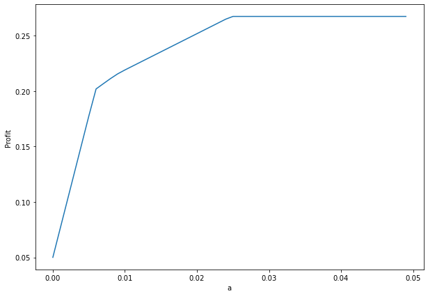

```python
#绘制风险偏好a与最大收益的曲线图
plt.figure(figsize=(10,7))
plt.plot(a_list,profit_list)
plt.xlabel('a');plt.ylabel('Profit')
```

**从上图中可以看出**

1. 风险越大，收益也就越大；
2. 当投资越分散时，投资者承担的风险越小，这与题意一致。即： 冒险的投资者会出现集中投资的情况，保守的投资者则尽量分散投资。
3. 在 $a=0.006$ 附近有一个转折点，在这点左边，风险增加很少时，利润增长很快。在这一点右边，风险增加很大时，利润增长很缓慢，所以对于风险和收益没有特殊偏好的投资者来说，应该选择曲线的拐点作为最优投资组合，大约是 $a=0.6\%$，总体收益为 $Q=20\%$，所对应投资方案为：风险度 $a = 0.006$，收益 $Q = 0.2019$，$x_0=0，x_1=0.24，x_2=0.4，x_3=0.1091, x_4=0.2212$

**模型求解的其他思路**

在上面的例子中，我们使用固定风险水平来最大化收益的方法来将多目标转化为单目标，也可考虑其他思路：

1.在总盈利在水平 $k$ 以上的情况下，寻找风险最低的投资方案，即：

$$ \begin{aligned} &{\min \left\{ \max {q_i x_i} \right\}}\\ \text{s.t.} & {\left\{ \begin{array}{l} {\displaystyle\sum_{i=1}^n (r_i - p_i) x_i \geq k}\\ { \displaystyle\sum_{i=1}^n (1+p_i)x_i = M}\\ { x_i \geq 0, i=1,2,...n} \end{array} \right.} \end{aligned} $$

2.对风险和收益赋予权重 $s(0 \leq s \leq 1)$ 和 $1-s$, $s$成为投资偏好系数，即

$$ \begin{aligned} & {\min \quad s\max \{q_ix_i\} - (1-s)\sum_{i=1}^n (r_i - p_i) x_i } \\ \text{s.t.}&\left\{\begin{array}{l} {\displaystyle \sum_{i=1}^n (1+p_i)x_i = M }\\ { x_i \geq 0, i=1,2,...n} \end{array}\right. \end{aligned} $$

案例2：运输问题(产销平衡) 某商品有$m$个产地，$n$个销地，各产地的产量分别为$a_1,a_2,\cdots,a_m$，各销地的需求量分别为$b_1,b_2,\cdots,b_n$。若该商品由$i$地运到$j$地的单位运价为$c_{ij}$，问应该如何调运才能使总运费最省？

**解：** 引入变量$x_{ij}$，其取值为由$i$地运往$j$地的商品数量，数学模型为

$$ \begin{aligned} &\min \sum_{i=1}^{m} \sum_{j=1}^{n} c_{i j} x_{i j}\\ s.t.&\left\{\begin{array}{ll} {\displaystyle \sum_{j=1}^{n} x_{i j}=a_{i},} & {i=1, \cdots, m} \\ {\displaystyle \sum_{i=1}^{m} x_{i j}=b_{j},} & {j=1,2, \cdots, n} \\ {x_{i j} \geq 0} \end{array}\right. \end{aligned} $$

**参考文献**

- ThomsonRen 的 github https://github.com/ThomsonRen/mathmodels
- 司守奎 的 《Python数学实验与建模》